# Contributing to EpiForsk

This vignette describes our recommended workflow for contributing your work to the EpiForsk package, using the [usethis](https://usethis.r-lib.org/index.html) package.

## Overview

There are a few steps you must complete the first time you want to contribute, or when you change computer:

1. Install git. You can get it from the software center.
2. Install the devtools package in R.
3. Generate a personal access token (PAT) to allow R access to the GitHub API.
4. fork-and-clone the EpiForsk repository to your work computer.

The next steps describe the workflow from starting work on a new contribution to merging into the source repository:

1. Create a new feature branch for developing your functions, vignettes, and other contributions.
2. Commit your work to your local feature branch with a description of its contents.
3. When your contribution is ready, initiate a pull request to the upstream git repository.
4. A package maintainer will look at your pull request, and may request changes. Resolve these issues and push your updates.
5. When all issues are resolved, your work will be merged to the main branch. You can now switch back to the default branch, pull upstream changes, and delete the feature branch.

## Managing Git Credentials

To get your git credentials set up, follow these steps:

1. Log into github.
2. Run `usethis::create_github_token()`. Alternatively, go to [github](https://github.com/settings/tokens) and click on “generate new token”.

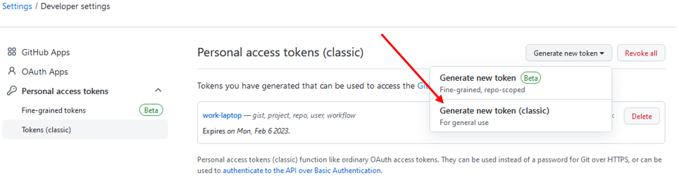

3. Fill out the form. When using `usethis::create_github_token()`, the scope has been pre-selected.

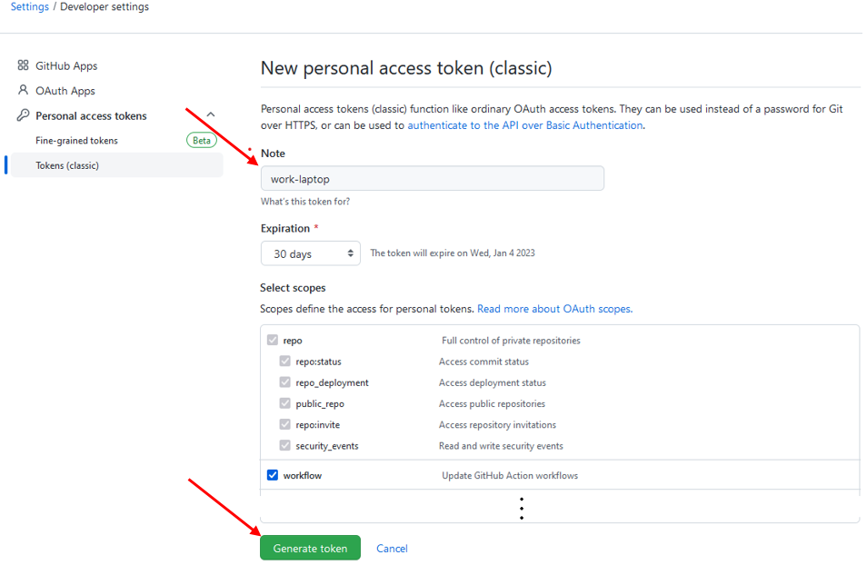

4. Copy the generated token and store it somewhere safe.

[figure not shown]

5. Run `gitcreds::gitcreds_set()` to register the token in the local Git credential store.

[figure not shown]

6. Remember to regenerate and restore your PAT on the schedule set in step 3. The default period recommended by github is 1 month.

For more details, you can read the usethis vignette [git-credentials](https://usethis.r-lib.org/articles/git-credentials.html).

## Clone the EpiForsk repository

To protect the source repository, you must copy it to your own github account, and then clone it to get a local copy. This is accomplished with

```r
usethis::create_from_github("https://github.com/Laksafoss/EpiForsk", fork = TRUE)
```

## Contribution workflow

When working on a contribution, do so on a separate feature branch. It is best practice to never make commits to the default branch of a fork. To create your feature branch, run

```r
usethis::pr_init("branch_name")
```

When you’re done working on your contribution, commit it to your local clone. This can be done using the git tab in R-studio. Remember to stage any file you want to include in your commit and write a descriptive commit message. It is ok to make multiple commits before initiating a [pull request](https://usethis.r-lib.org/articles/pr-functions.html). To do this, run

```r
usethis::pr_push()
```

This will open a webpage letting you initiate the PR. take note of the PR number, as this is used to reference the PR.

At this point, a package maintainer will look at your PR, and they will either accept it or request changes. If changes are requested, work on resolving the issues. Any changes you make must be committed to your local branch, then pushed upstream using `usethis::pr_push()`. If changes have been committed by the reviewer, you can pull these using `usethis::pr_pull()`.

When all issues are resolved, the PR will be accepted and merged into the source repository. At this point, you should run

```r
usethis::pr_finish("PR number")
```

This will switch you back to the default branch, pull changes from the source repository and delete the local feature branch.

## Additional

When preparing a contribution, you should put some thought into the format you use. We imagine most contributions will either be in the form of a vignette or a function.

Think of vignettes as an article, where you can write down thoughts and ideas in a free text format, as well as writing R code. This can be useful for sharing examples/guides on data management, analysis methods, r packages, and so on.

In contrast to vignettes, R functions have much stricter formal [requirements](https://r-pkgs.org/code.html). Use R functions when you need to automate a common task, such as a data management task. There are a lot of considerations to writing a good R function, and it will generally be a bigger commitment than writing a vignette. A function needs good documentation, explaining what it does and how to use it. It should also have comprehensive and descriptive error handling. The goal is not to make the sleekest, fastest and most efficient functions, but rather implementing functionalities tailored to our specific needs. With that said, writing functions is not a one and done process, and we encourage you to improve functions added to the package over time.

For a deep dive into writing packages, check out [Hadley’s R package book](https://r-pkgs.org/).